# DA5020.A9.YICHENG.ZHANG

YICHENG ZHANG

2022-11-14

```r
rm(list = ls())
library(dplyr)
library(ggplot2)
library(tidyverse)
library(lubridate)
library(tinytex)
```

# 1.

```r
df <- read_csv("https://data.sfgov.org/api/views/rkru-6vcg/rows.csv?accessType=DOWNLOAD")
# inspect the data
str(df)
```

```
## spec_tbl_df [24,967 × 12] (S3: spec_tbl_df/tbl_df/tbl/data.frame)
##  $ Activity Period            : num [1:24967] 200507 200507 200507 200507 200507 ...
##  $ Operating Airline          : chr [1:24967] "ATA Airlines" "ATA Airlines" "ATA Airlines" "Air Canada" ...
##  $ Operating Airline IATA Code: chr [1:24967] "TZ" "TZ" "TZ" "AC" ...
##  $ Published Airline          : chr [1:24967] "ATA Airlines" "ATA Airlines" "ATA Airlines" "Air Canada" ...
##  $ Published Airline IATA Code: chr [1:24967] "TZ" "TZ" "TZ" "AC" ...
##  $ GEO Summary                : chr [1:24967] "Domestic" "Domestic" "Domestic" "International" ...
##  $ GEO Region                 : chr [1:24967] "US" "US" "US" "Canada" ...
##  $ Activity Type Code         : chr [1:24967] "Deplaned" "Enplaned" "Thru / Transit" "Deplaned" ...
##  $ Price Category Code        : chr [1:24967] "Low Fare" "Low Fare" "Low Fare" "Other" ...
##  $ Terminal                   : chr [1:24967] "Terminal 1" "Terminal 1" "Terminal 1" "Terminal 1" ...
##  $ Boarding Area              : chr [1:24967] "B" "B" "B" "B" ...
##  $ Passenger Count            : num [1:24967] 27271 29131 5415 35156 34090 ...
##  - attr(*, "spec")=
##   .. cols(
##   ..   `Activity Period` = col_double(),
##   ..   `Operating Airline` = col_character(),
##   ..   `Operating Airline IATA Code` = col_character(),
##   ..   `Published Airline` = col_character(),
##   ..   `Published Airline IATA Code` = col_character(),
##   ..   `GEO Summary` = col_character(),
##   ..   `GEO Region` = col_character(),
##   ..   `Activity Type Code` = col_character(),
##   ..   `Price Category Code` = col_character(),
##   ..   Terminal = col_character(),
##   ..   `Boarding Area` = col_character(),
##   ..   `Passenger Count` = col_double()
##   .. )
##  - attr(*, "problems")=<externalptr>
```

```r
summary(df)
```

```
##  Activity Period  Operating Airline  Operating Airline IATA Code
##  Min.   :200507   Length:24967       Length:24967
##  1st Qu.:200912   Class :character   Class :character
##  Median :201406   Mode  :character   Mode  :character
##  Mean   :201377
##  3rd Qu.:201806
##  Max.   :202206
##  Published Airline  Published Airline IATA Code GEO Summary
##  Length:24967       Length:24967                Length:24967
##  Class :character   Class :character            Class :character
##  Mode  :character   Mode  :character            Mode  :character
##
##
##
##   GEO Region        Activity Type Code Price Category Code   Terminal
##  Length:24967       Length:24967       Length:24967        Length:24967
##  Class :character   Class :character   Class :character    Class :character
##  Mode  :character   Mode  :character   Mode  :character    Mode  :character
##
##
##
##  Boarding Area      Passenger Count
##  Length:24967       Min.   :     1
##  Class :character   1st Qu.:  4551
##  Mode  :character   Median :  8641
##                     Mean   : 28472
##                     3rd Qu.: 19520
##                     Max.   :659837
```

```r
glimpse(df)
```

```
## Rows: 24,967
## Columns: 12
## $ `Activity Period`             <dbl> 200507, 200507, 200507, 200507, 200507, …
## $ `Operating Airline`           <chr> "ATA Airlines", "ATA Airlines", "ATA Air…
## $ `Operating Airline IATA Code` <chr> "TZ", "TZ", "TZ", "AC", "AC", "CA", "CA"…
## $ `Published Airline`           <chr> "ATA Airlines", "ATA Airlines", "ATA Air…
## $ `Published Airline IATA Code` <chr> "TZ", "TZ", "TZ", "AC", "AC", "CA", "CA"…
## $ `GEO Summary`                 <chr> "Domestic", "Domestic", "Domestic", "Int…
## $ `GEO Region`                  <chr> "US", "US", "US", "Canada", "Canada", "A…
## $ `Activity Type Code`          <chr> "Deplaned", "Enplaned", "Thru / Transit"…
## $ `Price Category Code`         <chr> "Low Fare", "Low Fare", "Low Fare", "Oth…
## $ Terminal                      <chr> "Terminal 1", "Terminal 1", "Terminal 1"…
## $ `Boarding Area`               <chr> "B", "B", "B", "B", "B", "G", "G", "A", …
## $ `Passenger Count`             <dbl> 27271, 29131, 5415, 35156, 34090, 6263, …
```

```r
# view data:
head(df)
```

```
## # A tibble: 6 × 12
##   `Activity Period` `Operating Airline` `Operating Airline IA…` `Published Air…`
##               <dbl> <chr>               <chr>                   <chr>
## 1            200507 ATA Airlines        TZ                      ATA Airlines
## 2            200507 ATA Airlines        TZ                      ATA Airlines
## 3            200507 ATA Airlines        TZ                      ATA Airlines
## 4            200507 Air Canada          AC                      Air Canada
## 5            200507 Air Canada          AC                      Air Canada
## 6            200507 Air China           CA                      Air China
## # … with 8 more variables: `Published Airline IATA Code` <chr>,
## #   `GEO Summary` <chr>, `GEO Region` <chr>, `Activity Type Code` <chr>,
## #   `Price Category Code` <chr>, Terminal <chr>, `Boarding Area` <chr>,
## #   `Passenger Count` <dbl>
```

```r
tail(df)
```

```
## # A tibble: 6 × 12
##   `Activity Period` `Operating Airline`  `Operating Airline I…` `Published Air…`
##               <dbl> <chr>                <chr>                  <chr>
## 1            202206 Vietnam Airlines JSC VN                     Vietnam Airline…
## 2            202206 Vietnam Airlines JSC VN                     Vietnam Airline…
## 3            202206 Virgin Atlantic      VS                     Virgin Atlantic
## 4            202206 Virgin Atlantic      VS                     Virgin Atlantic
## 5            202206 WestJet Airlines     WS                     WestJet Airlines
## 6            202206 WestJet Airlines     WS                     WestJet Airlines
## # … with 8 more variables: `Published Airline IATA Code` <chr>,
## #   `GEO Summary` <chr>, `GEO Region` <chr>, `Activity Type Code` <chr>,
## #   `Price Category Code` <chr>, Terminal <chr>, `Boarding Area` <chr>,
## #   `Passenger Count` <dbl>
```

```r
# see column names of that data:
colnames(df)
```

```
##  [1] "Activity Period"             "Operating Airline"
##  [3] "Operating Airline IATA Code" "Published Airline"
##  [5] "Published Airline IATA Code" "GEO Summary"
##  [7] "GEO Region"                  "Activity Type Code"
##  [9] "Price Category Code"         "Terminal"
## [11] "Boarding Area"               "Passenger Count"
```

# 2.

```r
# we first want to tidy up our data little bit. Set the activity period into the correct year/month/date format:
df1 <- df %>%
  mutate(Date = as.Date(paste0(`Activity Period`, "01"), format="%Y%m%d"))%>%
  mutate(Year = year(Date), Month = month(Date))

# then we want only the domestic fly trip and occur in the march.
dfq2 <- df1 %>%
  filter(`GEO Summary` == 'Domestic')%>%
  filter(Month == 3) %>%
  group_by(Year) %>%
  summarise( total_passengers = sum(`Passenger Count`))

# table view:
dfq2
```

```
## # A tibble: 17 × 2
##     Year total_passengers
##    <dbl>            <dbl>
##  1  2006          2021211
##  2  2007          2085306
##  3  2008          2343637
##  4  2009          2279999
##  5  2010          2432351
##  6  2011          2444460
##  7  2012          2760730
##  8  2013          2860027
##  9  2014          2982900
## 10  2015          3157697
## 11  2016          3227881
## 12  2017          3350116
## 13  2018          3579413
## 14  2019          3449863
## 15  2020          1431537
## 16  2021          1029942
## 17  2022          2559920
```

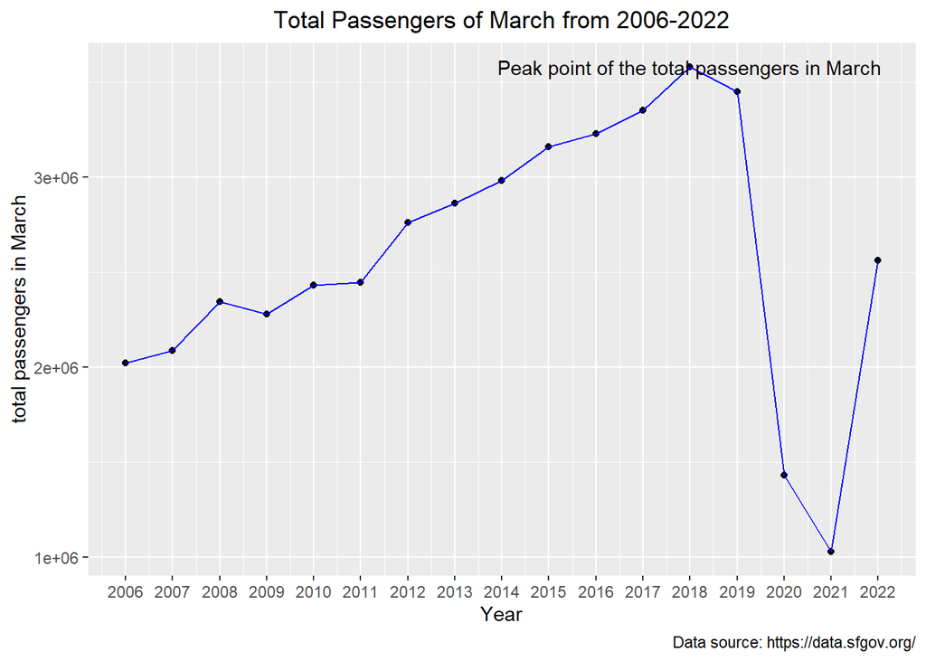

```r
# visualization
ggplot(dfq2, aes(x = Year, y = total_passengers)) +
  geom_point()+
  geom_line(color="blue") +
  annotate(geom="text", x=2018, y=3579413,
             label="Peak point of the total passengers in March")+
  scale_x_continuous(breaks=seq(2006, 2022, 1))+
  labs( y = "total passengers in March", title = "Total Passengers of March from 2006-2022", caption = "Data source: https://data.sfgov.org/")+
  theme(plot.title = element_text(hjust = 0.5))
```

From the result we can tell that from 2006 to 2018 we are having a very steady increasing trend of total passengers in march each year, and 2018 is also the peak point of this trend. However, start from 2018, we have a very huge decreasing of passengers on march and it decreased dramatically from 2019 to 2020, I think it mainly due to the outbreak of the COVID_19 pandemic and most people canceled their travel plan. Start from 2021, we hit the bottom point of the total passengers and then the trend starts to recover due to the travel policy in the US got back to normal.

# 3.

```r
# this is our predict result:
predict2019<-sum(dfq2[11:13,2])/3
predict2019
```

```
## [1] 3385803
```

```r
# this is real result from previous table:
dfq2[14,2]
```

```
## # A tibble: 1 × 1
##   total_passengers
##              <dbl>
## 1          3449863
```

```r
# our error is:
# use actual minus predicted value:
round(3449863-predict2019)
```

```
## [1] 64060
```

```r
# transfer it into rate to make our comparison more straightforward:
# we will use same appraoch (the percentage error value) in the later part of this assignment as well:
error<-abs(predict2019-3449863)/predict2019*100
error
```

```
## [1] 1.892008
```

From the result we can tell that our prediction for the 2019 march total passengers should be 3385803 and the actual total passenger is 3449863. The error is 64060 by using what we predicted to against the actual value ,so,if we transfer it into percentage error rate, our error rate is 1.892008% which is pretty low!

# 4.

```r
# we apply the different weights to the respective year and devided by the total weights
# this is our predicted value:
(dfq2[11,2] *3+dfq2[12,2]*5+ dfq2[13,2]*7)/(3+5+7)
```

```
##   total_passengers
## 1          3432674
```

```r
# error this time:
# use actual minus predicted value:
3449863-3432674
```

```
## [1] 17189
```

```r
# our error rate this time:
abs(3432674-3449863)/3432674*100
```

```
## [1] 0.5007466
```

From the result we can tell that our prediction for the weighted 2019 march total passengers should be 3432674 and the actual total passenger is 3449863. The error is 17189 this time, and if we transfer it into percentage, our error rate is 0.5007466% which is better than last time! The weighted moving average prediction model is more precise than the simple moving average model.

# 5.

```r
# By referring to the class vedio, we can have following function:
# use data start from 2008
dfq5 <- dfq2[3:17,]
dfq5$predict_total_passengers <- 0
dfq5$error_value <- 0
# initialize the first predict value:
dfq5$predict_total_passengers[1] <- dfq2$total_passengers[3]
alpha <- 0.7

for (i in 2:nrow(dfq5)) {
  dfq5$predict_total_passengers[i] <- dfq5$predict_total_passengers[i-1] + (alpha * dfq5$error_value[i-1])
  # use actual minus predicted value:
  dfq5$error_value[i] <-  round(dfq5$total_passengers[i] - dfq5$predict_total_passengers[i])
}

# view the result of the predict table:
dfq5
```

```
## # A tibble: 15 × 4
##     Year total_passengers predict_total_passengers error_value
##    <dbl>            <dbl>                    <dbl>       <dbl>
##  1  2008          2343637                 2343637            0
##  2  2009          2279999                 2343637       -63638
##  3  2010          2432351                 2299090.      133261
##  4  2011          2444460                 2392373.       52087
##  5  2012          2760730                 2428834       331896
##  6  2013          2860027                 2661161.      198866
##  7  2014          2982900                 2800367.      182533
##  8  2015          3157697                 2928141.      229556
##  9  2016          3227881                 3088830.      139051
## 10  2017          3350116                 3186165.      163951
## 11  2018          3579413                 3300931.      278482
## 12  2019          3449863                 3495869.      -46006
## 13  2020          1431537                 3463664.    -2032127
## 14  2021          1029942                 2041175.    -1011233
## 15  2022          2559920                 1333312.     1226608
```

```r
# error this time:
# use actual minus predicted value:
round(dfq5$total_passengers[dfq5$Year==2019]-dfq5$predict_total_passengers[dfq5$Year==2019])
```

```
## [1] -46006
```

```r
# we find out the error rate this time
abs(dfq5$predict_total_passengers[dfq5$Year==2019] - dfq5$total_passengers[dfq5$Year==2019])*100/dfq5$predict_total_passengers[dfq5$Year==2019]
```

```
## [1] 1.315996
```

From the table result we can see that we have the predicted passengers for 2019 in march as 3495868 and the actual total passengers is 3449863 which is 46006 (error value -46006) less than we predicted. We have a error rate of 1.315996% this time and this is actually higher than the 0.5007466% from last question we got by using the weighted moving average prediction model. Therefore I would say the weighted moving average prediction model is better than the exponential smoothing prediction.

# 6.

```r
lm_predict<-lm(total_passengers ~ Year, data = dfq2[3:13,])
lm_predict
```

```
##
## Call:
## lm(formula = total_passengers ~ Year, data = dfq2[3:13, ])
##
## Coefficients:
## (Intercept)         Year
##  -262394559       131769
```

Therefore we now have a linear regression predicting formula here:

$$total\ passengers=131769\times
Year-262394559$$

```r
# we apply 2019 and 2020 into our formula:
-262394559+131769*c(2019,2020)
```

```
## [1] 3647052 3778821
```

```r
# calculate the error:
# use actual minus predicted value:
3449863-3647052
```

```
## [1] -197189
```

```r
1431537-3778821
```

```
## [1] -2347284
```

```r
# calculating the error rate:
abs(3647052-3449863)*100/3647052
```

```
## [1] 5.406805
```

```r
abs(3778821-1431537)*100/3778821
```

```
## [1] 62.11683
```

From the result we can tell that our predicted total passengers for 2019 and 2020 are 3647052 and 3778821. However, the actual number of total passengers in march of these two years are 3449863 and 1431537. The error of 2019 is -197189 (with an error rate of 5.406805%); the error of 2020 is -2347284 (with an error rate of 62.11683%), both of these two errors is higher than previous predictions (especially for the second one) and I won’t consider these two prediction result as valid and we may want to be careful about whether we want to use linear regression model as prediction tool for this case. Time varying data may not suitable to use a linear regression for prediction when we cannot apply very specific time but only using a general aggregated years’ result.

# 7.

```r
# we first calculate the MSE of exponential model using the dfq5 table from previous question:
# we use data from 2008-2018 only:
dfq7.1<-dfq5[1:11,]
dfq7.1$squared_error<-dfq7.1$error_value^2
sum(dfq7.1$squared_error)/11
```

```
## [1] 34909597642
```

```r
# we now calculate the MSE for linear model using the dfq5 table and linear regression model from previous question:
lm_result <- lm_predict$coefficients[2] * dfq5[,1] + lm_predict$coefficients[1]
sum((lm_result[1:11,] - dfq5[1:11,2])^2)/11
```

```
## [1] 5017266497
```

From the result above, we know the MSE of the exponential model is 34909597642, and the MSE of the linear regression model is 5017266497. Thus, now we can say the linear regression model from Q6 has the smallest MSE, which is more precise than the exponential model.